# Two-Way ANOVA: From Additive Models to Interactions

Math 360 Statistical Modeling — Class Notes

## 1 The Gummy Bear Data

On Monday we launched gummy bears and recorded how far each one traveled under combinations of two factors: **height** of the ramp (3 levels) and **position** of the launcher on the ramp (3 levels), with 3 replications per treatment combination: 27 launches in total.

### 1.1 Read and inspect the data

```r
gummy <- read_csv("http://people.kzoo.edu/enordmoe/math360/gummybears2waydata.csv")
glimpse(gummy)
```

```
Rows: 27
Columns: 5
$ case        <dbl> 13, 14, 15, 4, 5, 6, 16, 17, 18, 22, 23, 24, 25, 26, 27, 1…
$ height      <dbl> 1, 1, 1, 1, 1, 1, 1, 1, 1, 2, 2, 2, 2, 2, 2, 2, 2, 2, 3, 3…
$ position    <dbl> 1, 1, 1, 2, 2, 2, 3, 3, 3, 1, 1, 1, 2, 2, 2, 3, 3, 3, 1, 1…
$ replication <dbl> 1, 2, 3, 1, 2, 3, 1, 2, 3, 1, 2, 3, 1, 2, 3, 1, 2, 3, 1, 2…
$ distance    <dbl> 84, 71, 121, 63, 128, 88, 63, 90, 107, 124, 95, 106, 173, …
```

**Important**

**Before we go further:** `height` and `position` are currently stored as integers (1, 2, 3). For ANOVA, they must be treated as **categorical** (factor) variables, not numeric ones. We will convert them now.

```r
gummy <- gummy |>
  mutate(
    height   = factor(height,   labels = c("Low", "Medium", "High")),
    position = factor(position, labels = c("One", "Two",    "Three"))
  )
glimpse(gummy)
```

```
Rows: 27
Columns: 5
$ case        <dbl> 13, 14, 15, 4, 5, 6, 16, 17, 18, 22, 23, 24, 25, 26, 27, 1…
$ height      <fct> Low, Low, Low, Low, Low, Low, Low, Low, Low, Medium, Mediu…
$ position    <fct> One, One, One, Two, Two, Two, Three, Three, Three, One, On…
$ replication <dbl> 1, 2, 3, 1, 2, 3, 1, 2, 3, 1, 2, 3, 1, 2, 3, 1, 2, 3, 1, 2…
$ distance    <dbl> 84, 71, 121, 63, 128, 88, 63, 90, 107, 124, 95, 106, 173, …
```

## 2 The Two-Way ANOVA Setup

### 2.1 Why two-way?

In one-way ANOVA we had a single categorical explanatory variable (factor) with $k$ levels. Now we have **two factors**: * $A$ (Height, with $I$ levels) * $B$ (Position, with $J$ levels).

Each unique combination of a level of $A$ with a level of $B$ is called a treatment **cell**. Here we have $I = 3$, $J = 3$, so $3 \times 3 = 9$ cells.

### 2.2 Balanced design

Our experiment is **balanced**: each cell contains three replications $K=3$, for a grand total $n=IJK = (3)(3)(3)=27$. Balanced designs greatly simplify the algebra and interpretation.

### 2.3 The two models we will build

| Model | Question it answers |
| --- | --- |
| **Additive (no interaction)** | Do *height* and *position* have separate, independent effects on distance? |
| **Interaction** | Does the effect of height *depend on* the *position* of the launcher (and vice versa)? |

We will fit the simpler model first, check whether its assumptions are plausible, and then decide whether we need the richer interaction model.

## 3 Exploratory Analysis

### 3.1 Cell means and standard deviations

```r
favstats(distance ~ height + position, data = gummy)
```

```
  height.position min    Q1 median    Q3 max      mean       sd n missing
1         Low.One  71  77.5     84 102.5 121  92.00000 25.94224 3       0
2      Medium.One  95 100.5    106 115.0 124 108.33333 14.64013 3       0
3        High.One 128 136.0    144 149.5 155 142.33333 13.57694 3       0
4         Low.Two  63  75.5     88 108.0 128  93.00000 32.78719 3       0
5      Medium.Two  87 130.0    173 177.5 182 147.33333 52.44362 3       0
6        High.Two 114 122.0    130 152.5 175 139.66667 31.62805 3       0
7       Low.Three  63  76.5     90  98.5 107  86.66667 22.18859 3       0
8    Medium.Three  89 112.5    136 138.0 140 121.66667 28.36077 3       0
9      High.Three 128 163.0    198 212.0 226 184.00000 50.47772 3       0
```

It is helpful to arrange these as a grid. Here’s a concise way to do this with Base R:

```r
tapply(gummy$distance, list(gummy$height, gummy$position), mean)
```

```
            One      Two     Three
Low     92.0000  93.0000  86.66667
Medium 108.3333 147.3333 121.66667
High   142.3333 139.6667 184.00000
```

Scan across each row (fixed height, varying position) and down each column (fixed position, varying height).

- Do the row means increase or decrease consistently?
- Do the column means?
- Are any cells noticeably out of line with the rest?

### 3.2 Design (main-effects) plot

The `plot.design()` function shows the **marginal means,** the mean distance averaged over all levels of the *other* factor, for each level of each factor.

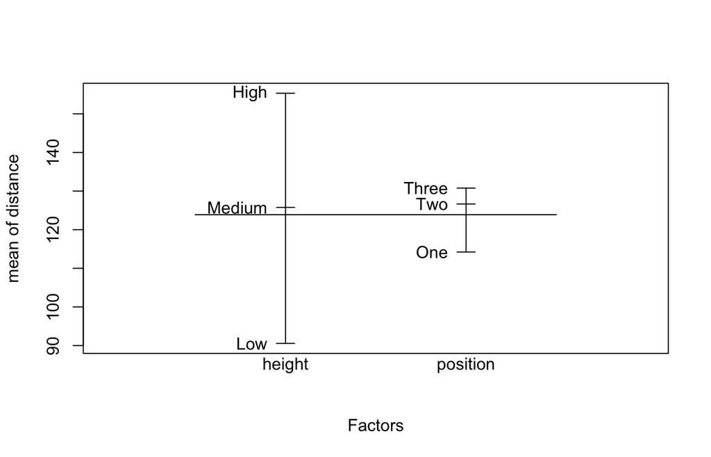

Main-effects plot: Marginal Means for height and position

```r
plot.design(distance ~ height + position, data = gummy)
```

**What to look for:** Large differences in marginal means suggest strong main effects. If the differences are much larger for one factor than the other, that factor likely has a stronger effect on distance.

### 3.3 Interaction plot

The **interaction plot** reveals whether the two factors operate independently.

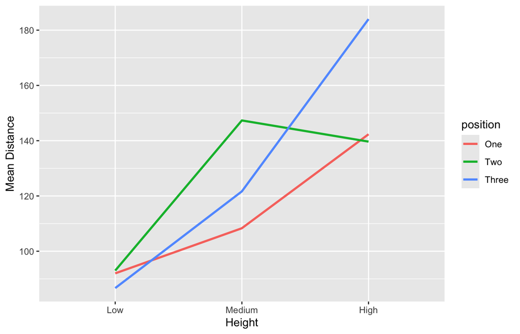

Interaction plot: mean distance by height, grouped by position

```r
gf_summary(distance ~ height, color = ~position,
           group = ~position, fun = mean, geom = "line",
           xlab = "Height", ylab = "Mean Distance",
           data = gummy)
```

**What to look for:**

- **Parallel lines** $\Rightarrow$ the factors act *additively*; the effect of height is the same regardless of position.
- **Non-parallel (crossing or converging) lines** $\Rightarrow$ evidence of an **interaction**; the effect of one factor changes depending on the level of the other.

**Tip**

**Discussion:** What do you see in the interaction plot for your group’s gummy data? Are the lines roughly parallel, or do they cross/converge?

## 4 The Two-Way Additive Model

### 4.1 Model notation

The **two-way additive model** (also called the *main-effects model*) can be written:

$$Y_{ijk} = \mu + \alpha_i + \beta_j + \varepsilon_{ijk}$$

where

| Symbol | Meaning |
| --- | --- |
| $Y_{ijk}$ | Observed distance for Height level $i$, Position level $j$, replication $k$ |
| $\mu$ | Overall (grand) mean |
| $\alpha_i$ | **Main effect of Height** level $i$ (deviation from $\mu$) |
| $\beta_j$ | **Main effect of Position** level $j$ (deviation from $\mu$) |
| $\varepsilon_{ijk}$ | Random error, assumed $\sim N(0, \sigma^2)$ |

The key assumption here is that the effect of Height ($\alpha_i$) is the **same at every level of Position**, and vice versa. That is, the effect is “additive.”

Once again, $\sum_i \alpha_i = 0$ and $\sum_j \beta_j = 0$, the effects add to 0 to allow estimation of the model.

### 4.2 Fit the additive model

```r
mod_add <- aov(distance ~ height + position, data = gummy)
summary(mod_add)
```

```
            Df Sum Sq Mean Sq F value  Pr(>F)
height       2  18931    9465   8.576 0.00176 **
position     2   1338     669   0.606 0.55443
Residuals   22  24282    1104
---
Signif. codes:  0 '***' 0.001 '**' 0.01 '*' 0.05 '.' 0.1 ' ' 1
```

### 4.3 Reading the ANOVA table

The table partitions the total variability in distance into three pieces:

| Source | SS | df | MS | F |
| --- | --- | --- | --- | --- |
| Height | $SS_A$ | $I-1 = 2$ | $MS_A$ | $MS_A / MS_E$ |
| Position | $SS_B$ | $J-1 = 2$ | $MS_B$ | $MS_B / MS_E$ |
| Residuals | $SS_E$ | $(n - I - J + 1)$ | $MS_E$ | — |

The *F*-statistic for each factor tests whether that factor’s marginal means are all equal, **after accounting for the other factor**.

**Note**

**Degrees of freedom check:** With $n = 27$, $I = 3$, $I = 3$:

- Height: $df = 3 - 1 = 2$
- Position: $df = 3 - 1 = 2$
- Residuals: $df = 27 - 3 - 3 + 1 = 22$
- Total: $df = n-1 = 26$ ✓

### 4.4 Residual diagnostics for the additive model

Before accepting the model, we check the three key conditions:

1. **Constant variance** (residuals spread equally across fitted values)
2. **Normality** of residuals
3. **Independence** (ideally, guaranteed by randomization of treatment order)

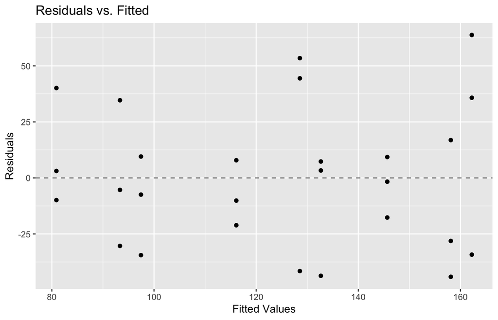

Residual diagnostics: additive model

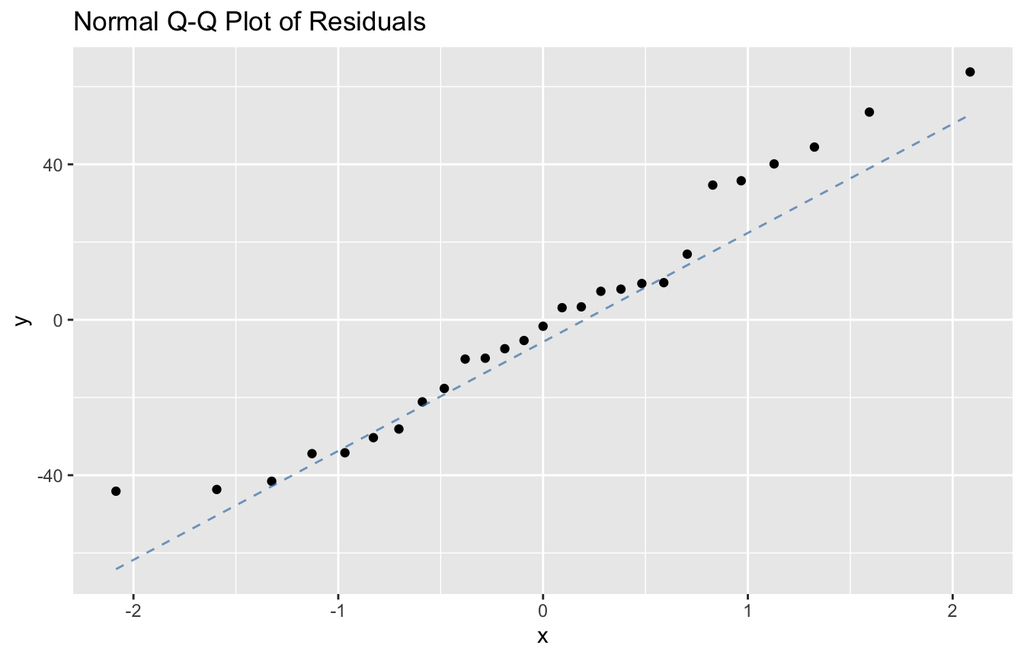

Residual diagnostics: additive model

```r
gf_point(resid(mod_add) ~ fitted(mod_add),
         xlab = "Fitted Values", ylab = "Residuals",
         title = "Residuals vs. Fitted") |>
  gf_hline(yintercept = ~0, linetype = "dashed", color = "gray50")
gf_qq(~resid(mod_add), title = "Normal Q-Q Plot of Residuals") |>
  gf_qqline(color = "steelblue")
```

**Tip**

**Discussion:**  
Do the residuals fan out as fitted values increase (suggesting non-constant variance)?  
Does the Q-Q plot follow the reference line closely?

### 4.5 Model effects

The `model.tables()` function extracts the estimated effects $\hat\alpha_i$ and $\hat\beta_j$:

```r
model.tables(mod_add, type = "effects")
```

```
Tables of effects

 height
height
   Low Medium   High
-33.33   1.89  31.44

 position
position
   One    Two  Three
-9.667  2.778  6.889
```

And the cell means predicted by the additive model:

```r
model.tables(mod_add, type = "means")
```

```
Tables of means
Grand mean

123.8889

 height
height
   Low Medium   High
 90.56 125.78 155.33

 position
position
   One    Two  Three
114.22 126.67 130.78
```

## 5 The Two-Way Interaction Model

### 5.1 Why consider an interaction?

If the lines in the interaction plot are *not* parallel, the additive model is **misspecified**; it will leave systematic patterns in the residuals and produce misleading tests. We need to add a term that captures how the two factors work together.

### 5.2 Model notation

The **interaction model** adds a term $(\alpha\beta)_{ij}$ for each cell and thus requires replications in each cell:

$$Y_{ijk} = \mu + \alpha_i + \beta_j + (\alpha\beta)_{ij} + \varepsilon_{ijk}$$

| Symbol | Meaning |
| --- | --- |
| $(\alpha\beta)_{ij}$ | Interaction effect for cell $(i,j)$: extra deviation beyond what the main effects alone predict |

This model has the constraint that $\sum_i (\alpha\beta)_{ij} = 0$ for all $j$, and $\sum_j (\alpha\beta)_{ij} = 0$ for all $i$.

Conceptually: if there is **no interaction**, then $(\alpha\beta)_{ij} = 0$ for all cells and the model collapses back to the additive one which is “nested” in this model.

### 5.3 Degrees of freedom

Adding the interaction term “uses up” additional degrees of freedom:

| Source | df |
| --- | --- |
| Height ($A$) | $I - 1 = 2$ |
| Position ($B$) | $J - 1 = 2$ |
| Height × Position | $(I-1)(J-1) = 4$ |
| Residuals | $IJ(K-1) = 9 \times 2 = 18$ |
| **Total** | $n-1=26$ |

Adding the interaction term uses up 4 more degrees of freedom, leaving fewer for estimating error, which makes it harder to detect real effects. So we only add it if the data give us good reason to.

### 5.4 Fit the interaction model

As we saw earlier in the term, putting the `*` operator between two factors in the model specification automatically includes both main effects **and** their interaction:

```r
mod_int <- aov(distance ~ height * position, data = gummy)
summary(mod_int)
```

```
                Df Sum Sq Mean Sq F value  Pr(>F)
height           2  18931    9465   8.745 0.00222 **
position         2   1338     669   0.618 0.55015
height:position  4   4798    1200   1.108 0.38309
Residuals       18  19484    1082
---
Signif. codes:  0 '***' 0.001 '**' 0.01 '*' 0.05 '.' 0.1 ' ' 1
```

**Note**

Recall that `height * position` is shorthand for `height + position + height:position`. You can also write the interaction term explicitly as `height:position`.

### 5.5 Interpreting the interaction F-test

The `height:position` row tests $H_0$: all $(\alpha\beta)_{ij} = 0$ (i.e., the additive model is adequate) against $H_a$: at least one interaction term is nonzero.

- **Large F, small p-value** ⇒ retain the interaction model.
- **Small F, large p-value** ⇒ the additive model may be sufficient.

**Tip**

**Discussion:** What does the interaction F-test tell you about your gummy bears data?

### 5.6 Residual diagnostics for the interaction model

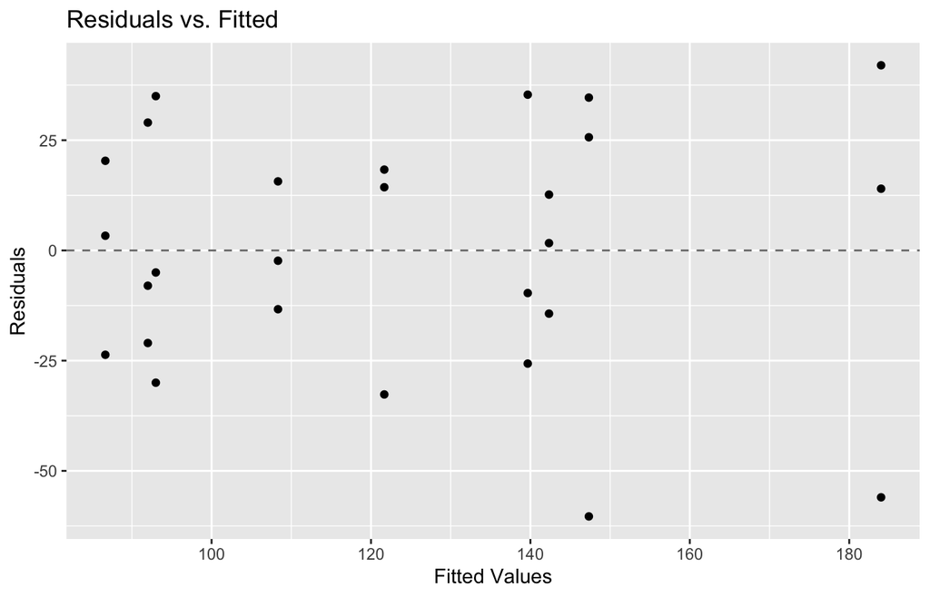

Residual diagnostics: interaction model

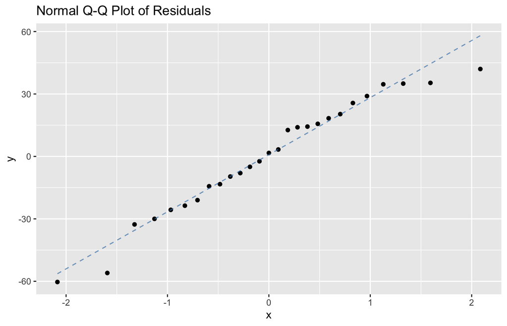

Residual diagnostics: interaction model

```r
gf_point(resid(mod_int) ~ fitted(mod_int),
         xlab = "Fitted Values", ylab = "Residuals",
         title = "Residuals vs. Fitted") |>
  gf_hline(yintercept = ~0, linetype = "dashed", color = "gray50")
gf_qq(~resid(mod_int), title = "Normal Q-Q Plot of Residuals") |>
  gf_qqline(color = "steelblue")
```

Compare these plots to those from the additive model. Does adding the interaction term clean up any systematic pattern in *your* residuals?

### 5.7 Interaction effects

```r
model.tables(mod_int, type = "effects")
```

```
Tables of effects

 height
height
   Low Medium   High
-33.33   1.89  31.44

 position
position
   One    Two  Three
-9.667  2.778  6.889

 height:position
        position
height   One     Two     Three
  Low     11.111  -0.333 -10.778
  Medium  -7.778  18.778 -11.000
  High    -3.333 -18.444  21.778
```

Scan the interaction effects table. Large positive values indicate cells where the observed mean *exceeds* what the main effects alone predict; large negative values indicate cells that *fall short*. Non-trivial values here are a sign that interaction is real and meaningful. But interaction effects may be hard to detect with just 3 replications per cell.

**Tip**

**Try it:** What happens if you replace `type = "effects"` with `type = "means"` in the `model.tables()` for the interaction model?

## 6 Model Comparison and Selection

To decide formally between the additive and interaction models, we can compare them directly. The interaction F-test in the `summary()` output already does this, but let’s see it explicitly:

```r
anova(mod_add, mod_int)
```

```
Analysis of Variance Table

Model 1: distance ~ height + position
Model 2: distance ~ height * position
  Res.Df   RSS Df Sum of Sq      F Pr(>F)
1     22 24282
2     18 19484  4    4798.2 1.1082 0.3831
```

The extra-sum-of-squares F-test asks: does adding the interaction term significantly reduce the residual sum of squares (taking into account the degrees of freedom required)?

### 6.1 Which model should we use?

Use the following decision process:

1. **Look at the interaction plot.** Are the lines noticeably non-parallel?
2. **Check the interaction F-test p-value.** Is it below your chosen $\alpha$?
3. **Compare residual diagnostics.** Does the interaction model satisfy conditions better?

If the interaction is statistically significant *and* practically meaningful, use the interaction model. Otherwise, the simpler additive model is preferred.

## 7 Post-Hoc Comparisons with Tukey’s Method

When we reject the null hypothesis of equal means, we often want to know *which* groups differ. Tukey’s HSD (Honestly Significant Difference) method controls the family-wise error rate across all pairwise comparisons.

**Important**

**When is Tukey’s method appropriate here?**

- For the **additive model**: Tukey comparisons for `height` and `position` separately are straightforward and interpretable.
- For the **interaction model**: comparisons are most meaningful for the *cell means* (all Height × Position combinations). With 9 cells there are $\binom{9}{2} = 36$ pairwise comparisons. Use judgment about which to report since not all will be of interest.

### 7.1 Tukey comparisons for the additive model

```r
TukeyHSD(mod_add)
```

```
  Tukey multiple comparisons of means
    95% family-wise confidence level

Fit: aov(formula = distance ~ height + position, data = gummy)

$height
                diff       lwr       upr     p adj
Medium-Low  35.22222 -4.119845  74.56429 0.0849289
High-Low    64.77778 25.435711 104.11984 0.0012099
High-Medium 29.55556 -9.786511  68.89762 0.1660307

$position
               diff       lwr      upr     p adj
Two-One   12.444444 -26.89762 51.78651 0.7101797
Three-One 16.555556 -22.78651 55.89762 0.5498801
Three-Two  4.111111 -35.23096 43.45318 0.9627908
```

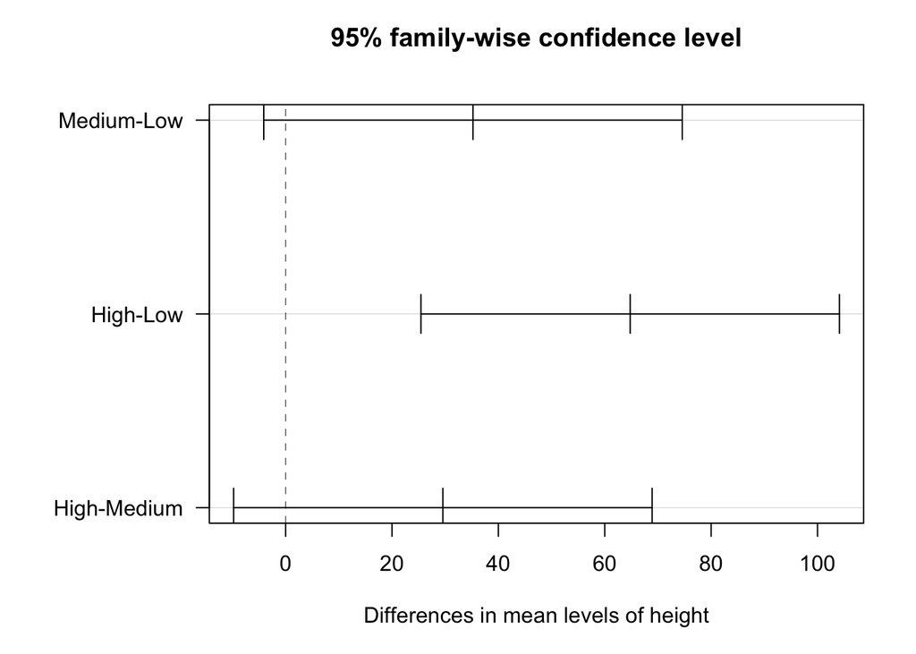

Tukey 95% family-wise CI: additive model

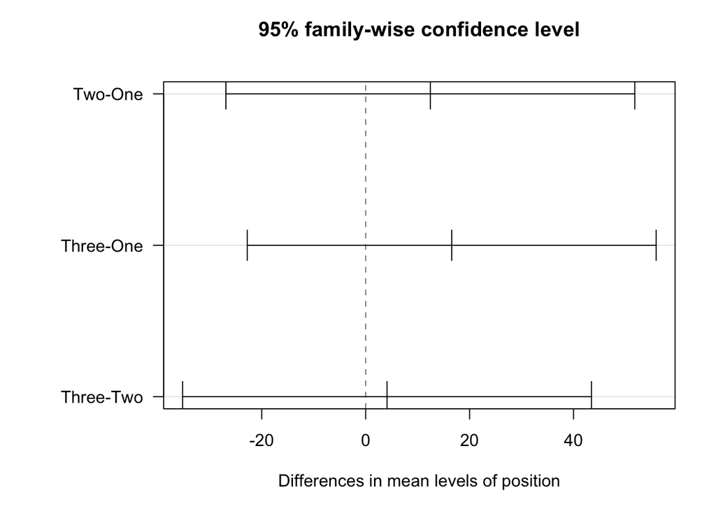

Tukey 95% family-wise CI: additive model

```r
par(las = 1, mar = c(5, 8, 4, 2)) # to allow space for labels
plot(TukeyHSD(mod_add))
```

```r
par(las = 0, mar = c(5, 4, 4, 2))   # restore defaults
```

Intervals that **do not include zero** correspond to pairs of groups whose means differ significantly at the family-wise 5% level.

### 7.2 Tukey comparisons for cell means (interaction model)

If the interaction is significant, it makes more sense to compare individual *cells* (Height × Position combinations):

```r
TukeyHSD(mod_int, which = "height:position")
```

```
  Tukey multiple comparisons of means
    95% family-wise confidence level

Fit: aov(formula = distance ~ height * position, data = gummy)

$`height:position`
                              diff         lwr       upr     p adj
Medium:One-Low:One       16.333333  -77.791491 110.45816 0.9993159
High:One-Low:One         50.333333  -43.791491 144.45816 0.6379278
Low:Two-Low:One           1.000000  -93.124824  95.12482 1.0000000
Medium:Two-Low:One       55.333333  -38.791491 149.45816 0.5259590
High:Two-Low:One         47.666667  -46.458158 141.79149 0.6968325
Low:Three-Low:One        -5.333333  -99.458158  88.79149 0.9999999
Medium:Three-Low:One     29.666667  -64.458158 123.79149 0.9660334
High:Three-Low:One       92.000000   -2.124824 186.12482 0.0583099
High:One-Medium:One      34.000000  -60.124824 128.12482 0.9290491
Low:Two-Medium:One      -15.333333 -109.458158  78.79149 0.9995668
Medium:Two-Medium:One    39.000000  -55.124824 133.12482 0.8628679
High:Two-Medium:One      31.333333  -62.791491 125.45816 0.9539490
Low:Three-Medium:One    -21.666667 -115.791491  72.45816 0.9951463
Medium:Three-Medium:One  13.333333  -80.791491 107.45816 0.9998453
High:Three-Medium:One    75.666667  -18.458158 169.79149 0.1770249
Low:Two-High:One        -49.333333 -143.458158  44.79149 0.6602168
Medium:Two-High:One       5.000000  -89.124824  99.12482 0.9999999
High:Two-High:One        -2.666667  -96.791491  91.45816 1.0000000
Low:Three-High:One      -55.666667 -149.791491  38.45816 0.5186027
Medium:Three-High:One   -20.666667 -114.791491  73.45816 0.9964625
High:Three-High:One      41.666667  -52.458158 135.79149 0.8176637
Medium:Two-Low:Two       54.333333  -39.791491 148.45816 0.5481709
High:Two-Low:Two         46.666667  -47.458158 140.79149 0.7183461
Low:Three-Low:Two        -6.333333 -100.458158  87.79149 0.9999995
Medium:Three-Low:Two     28.666667  -65.458158 122.79149 0.9720994
High:Three-Low:Two       91.000000   -3.124824 185.12482 0.0626490
High:Two-Medium:Two      -7.666667 -101.791491  86.45816 0.9999978
Low:Three-Medium:Two    -60.666667 -154.791491  33.45816 0.4127370
Medium:Three-Medium:Two -25.666667 -119.791491  68.45816 0.9856108
High:Three-Medium:Two    36.666667  -57.458158 130.79149 0.8969119
Low:Three-High:Two      -53.000000 -147.124824  41.12482 0.5780282
Medium:Three-High:Two   -18.000000 -112.124824  76.12482 0.9986350
High:Three-High:Two      44.333333  -49.791491 138.45816 0.7666774
Medium:Three-Low:Three   35.000000  -59.124824 129.12482 0.9178557
High:Three-Low:Three     97.333333    3.208509 191.45816 0.0395271
High:Three-Medium:Three  62.333333  -31.791491 156.45816 0.3799257
```

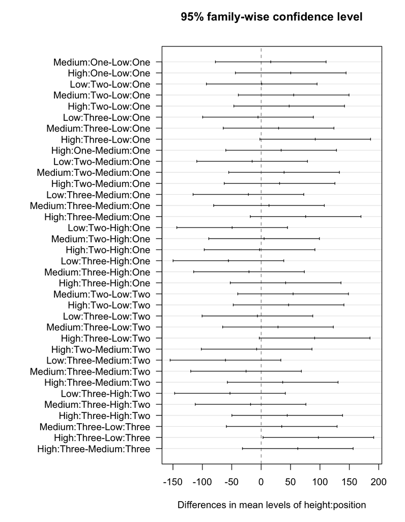

Tukey 95% family-wise CI: interaction cells

```r
par(las = 1, mar = c(5, 14, 4, 2))
plot(TukeyHSD(mod_int, which = "height:position"))
```

```r
par(las = 0, mar = c(5, 4, 4, 2))
```

**Tip**

**Discussion:** Focus on the comparisons that are most interesting to your group. Which Height × Position combinations produce significantly different distances?

## 8 Summary and Big Ideas

### 8.1 The two-way ANOVA framework

|  | Additive model | Interaction model |
| --- | --- | --- |
| **Formula** | `aov(Y ~ A + B)` | `aov(Y ~ A * B)` |
| **Key assumption** | Effects of A and B are independent and simply add | The effect of A may differ across levels of B |
| **Interaction term** | Absent | $(\alpha\beta)_{ij}$ |
| **Residual df** | $n - I - J + 1$ | $IJ(K-1)$ |
| **Interaction plot** | Lines parallel | Lines non-parallel |
| **Post-hoc** | Tukey on A and B separately | Tukey on A:B cells |